# 경제자료분석과 예측 - #01 시계열 자료

경제학과 김현학 교수

2025년 2학기

# 1 시계열 데이터란?

- 시계열 데이터는 동일한 관찰 단위에서 여러 시간대에 걸쳐 수집된 데이터이다. -한 국가의 총소비와 국내총생산(GDP) (예를 들어 20년 간의 분기별 관측치 = 80개의 관측치)
- 엔/달러, 파운드/달러, 유로/달러 환율 (1년간의 일별 데이터 = 365개의 관측치)
- 연도별 캘리포니아의 1인당 담배 소비량 (연간 데이터)

# 2 수업 목표와 로드맵

- 실전 데이터(ECOS API)로 **실질 GDP(분기)**를 불러오고 전처리한다.
- **STL 분해**(추세/계절/잔차)와 **HP 필터**로 순환·불규칙을 살펴본다.
- **정상성(Stationarity)** 개념과 **ADF/PP/KPSS/Zivot–Andrews** 검정을 실습한다.
- **AR 모형** 적합, **AIC/BIC**, **잔차 진단**(Ljung–Box), **예측 성능(MSFE)**을 비교한다.
- **시뮬레이션 기반 Fan Chart**로 불확실성을 시각화한다.
- **ARDL**(Autoregressive Distributed Lag) 아이디어와 자동·수동 적합을 실습한다.

> **핵심 이론 한눈에**  
> - **정상성**: 평균·분산·공분산이 시간에 따라 변하지 않는 성질. 회귀/예측의 많은 이론이 정상성 가정에 기반.  
> - **비정상** 시계열(추세/계절 포함)은 **차분/로그변환/계절조정** 등으로 정상화 후 모형화하는 것이 보통.  
> - **단위근(Unit Root)**: 시계열에 랜덤워크 성분이 존재한다는 뜻. 단위근이 있으면 추세(확률적 추세)가 나타나며, 보통 차분으로 제거.  
> - **모형선정**: AIC/BIC로 과대적합을 경계하며 예측력/해석력을 균형 있게 선택.  
> - **ARDL**: 종속변수의 시차와 설명변수의 시차를 함께 포함. 단기·장기 효과를 동시에 다룰 수 있어 경제학에서 실전적으로 유용.

# 3 패키지와 환경

```r
# 데이터 수집/처리
library(httr)
library(jsonlite)
library(zoo)
```

```r
# 시각화/통계
library(ggplot2)
library(forecast)
library(mFilter)
library(tseries)

# ARDL
# install.packages("ARDL")  # 최초 1회
library(ARDL)
# fan chart
# install.packages("fanplot")  # 최초 1회
library(fanplot)
```

# 4 ECOS API로 GDP 불러오기

> **데이터 정의**  
> - 국내총생산에 대한 지출(원계열, **실질**, 분기): 코드 **200Y110**, 항목 **10601**, 주기 **Q**  
> - 기간: 2000Q1 ~ 2024Q4

```r
url_base <- "http://ecos.bok.or.kr/api/StatisticSearch"

# ⚠️ 본인 API 키로 교체
id <- "Your key"

요청유형 <- "json"
언어구분 <- "kr"
요청시작건수 <- "1"
요청종료건수 <- "1000"
통계표코드 <- "200Y110"   # 실질, 원계열
주기 <- "Q"
검색시작일자 <- "2000Q1"
검색종료일자 <- "2024Q4"
통계항목코드1 <- "10601"

url <- paste(url_base, id, 요청유형, 언어구분, 요청시작건수, 요청종료건수,
             통계표코드, 주기, 검색시작일자, 검색종료일자, 통계항목코드1, sep="/")

api_result <- GET(url)
stopifnot(status_code(api_result) == 200)

res_chr <- rawToChar(api_result$content)
Encoding(res_chr) <- "UTF-8"
res_json <- fromJSON(res_chr)

out_df <- as.data.frame(res_json)

# 필요한 컬럼만: 분기(시간), 값
GDPdata <- out_df[, c(14, 15)]
colnames(GDPdata) <- c("Quarter","GDP_level")

# 타입 정리
GDPdata$Quarter   <- as.yearqtr(GDPdata$Quarter, format = "%YQ%q")
GDPdata$GDP_level <- as.numeric(GDPdata$GDP_level)

head(GDPdata)
```

```
##   Quarter GDP_level
## 1 2000 Q1  232345.4
## 2 2000 Q2  248927.2
## 3 2000 Q3  254491.2
## 4 2000 Q4  262525.3
## 5 2001 Q1  243975.1
## 6 2001 Q2  261120.4
```

> **주의**: ECOS 원계열은 계절조정 전 값. 계절성이 강하므로 모형화 전 분해/변환을 고려한다.

# 5 시계열 구성요소 분해: STL + HP

> **이론 요약**  
> - **STL 분해**: 원계열 = **추세(Trend)** + **계절(Seasonal)** + **잔차(Remainder)**. Loess 평활을 이용.  
> - **HP 필터**: 저주파(추세)와 고주파(순환)를 분리하는 스무딩 필터. 주로 거시경제 순환 성분을 추출하는 데 사용. 분기자료는 일반적으로 λ=1600을 사용.

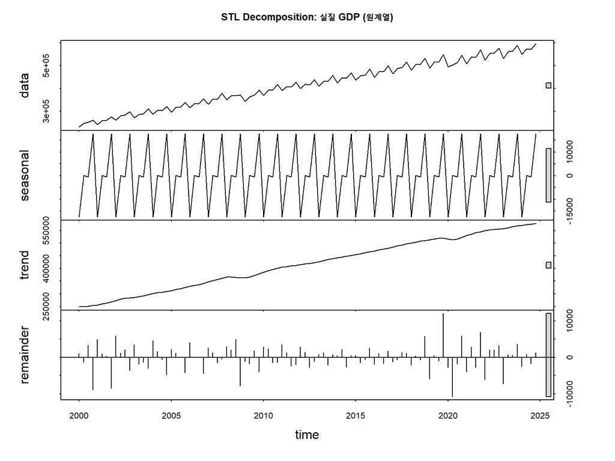

```r
kr_gdp_ts <- ts(GDPdata$GDP_level, start=c(2000,1), frequency=4)

stl_result <- stl(kr_gdp_ts, s.window = "periodic")
plot(stl_result, main = "STL Decomposition: 실질 GDP (원계열)")
```

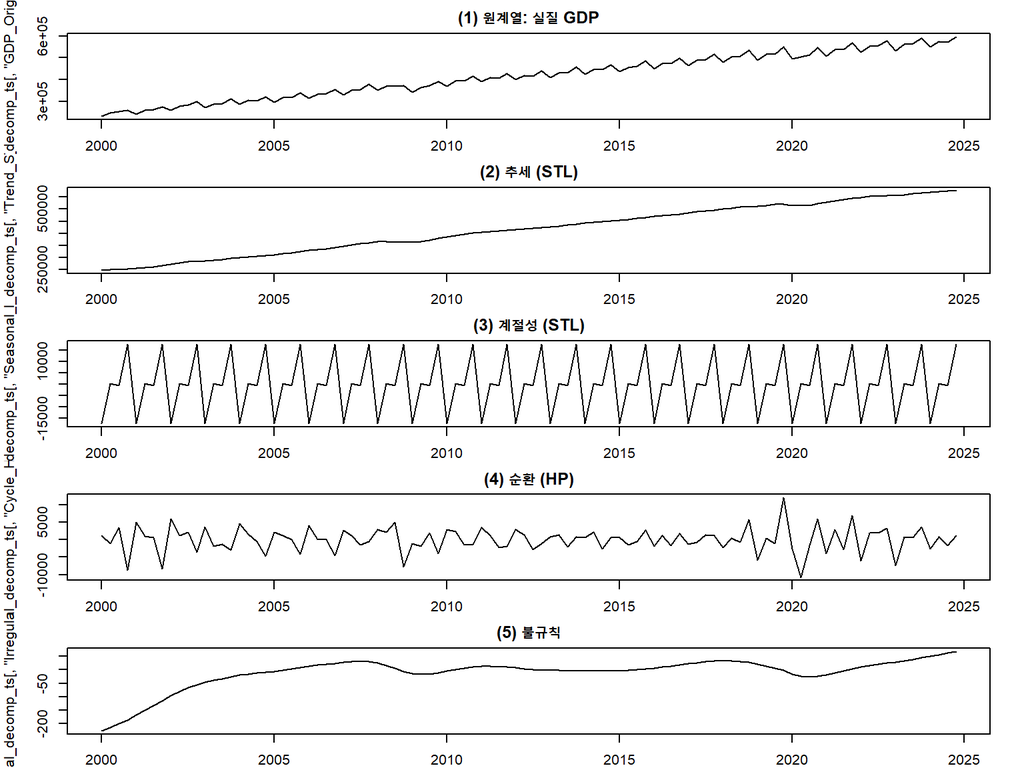

```r
seasonal_stl  <- stl_result$time.series[,"seasonal"]
trend_stl     <- stl_result$time.series[,"trend"]
remainder_stl <- stl_result$time.series[,"remainder"]

# remainder에서 HP 필터로 '순환' 강조
hp_result <- hpfilter(remainder_stl, freq = 1600, drift = FALSE)
cycle_hp  <- hp_result$cycle
irregular <- remainder_stl - cycle_hp

final_decomp_ts <- cbind(
  GDP_Original = kr_gdp_ts,
  Trend_STL = trend_stl,
  Seasonal_STL = seasonal_stl,
  Cycle_HP = cycle_hp,
  Irregular = irregular
)

par(mfrow=c(5,1), mar=c(2,4,2,2))
plot(final_decomp_ts[,"GDP_Original"], main="(1) 원계열: 실질 GDP")
plot(final_decomp_ts[,"Trend_STL"],    main="(2) 추세 (STL)")
plot(final_decomp_ts[,"Seasonal_STL"], main="(3) 계절성 (STL)")
plot(final_decomp_ts[,"Cycle_HP"],     main="(4) 순환 (HP)")
plot(final_decomp_ts[,"Irregular"],    main="(5) 불규칙")
```

```r
par(mfrow=c(1,1))
```

# 6 성장률 변환(QoQ, YoY)

> **이론 요약**  
> - 로그 차분은 **성장률** 근사.  
> - 분기 전기 대비 연율화: $\Delta \log y_t \times 400$  
> - 전년동기 대비: $\Delta_4 \log y_t \times 100$

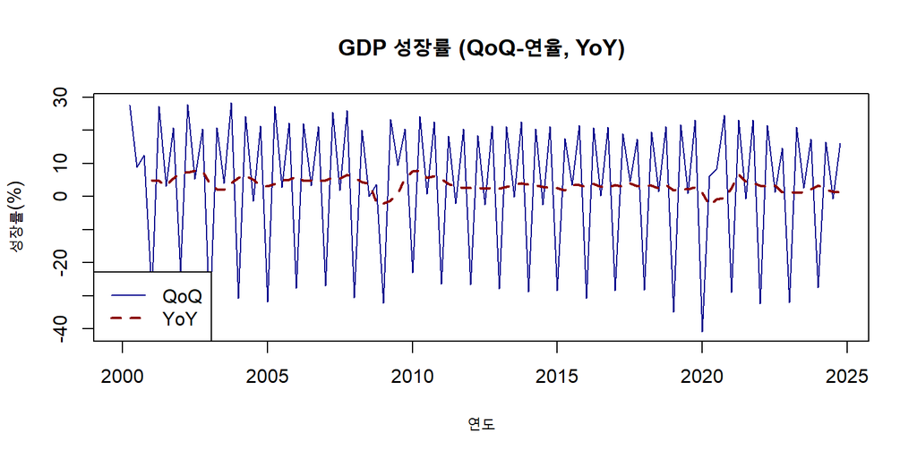

```r
GDPdata$QoQ <- c(NA, diff(log(GDPdata$GDP_level), lag = 1) * 400)
GDPdata$YoY <- c(rep(NA,4), diff(log(GDPdata$GDP_level), lag = 4) * 100)

GDPgrowth <- ts(cbind(QoQ = GDPdata$QoQ, YoY = GDPdata$YoY),
                frequency = 4, start = c(2000,1))

ts.plot(GDPgrowth,
        gpars = list(xlab = "연도", ylab = "성장률(%)",
                     main = "GDP 성장률 (QoQ-연율, YoY)",
                     lwd = c(1,2), lty = c(1,2),
                     col = c("darkblue","darkred")))
legend("bottomleft", c("QoQ","YoY"), lwd=c(1,2), lty=c(1,2),
       col=c("darkblue","darkred"))
```

# 7 정상성 & 단위근 검정

> **핵심 아이디어**  
> - 단위근(비정상)을 **ADF/PP**가 검정(귀무: 단위근 있음), **KPSS**는 반대로 정상성을 귀무로 둔다.  
> - **구조적 변화**가 있으면 단순 ADF로는 기각이 어려울 수 있어 **Zivot–Andrews**(단일 변동점) 검정이 도움.

```r
data("AirPassengers")  # 월별, 계절/추세 뚜렷한 예시
ap <- AirPassengers

# ADF
adf.test(ap)    # H0: 단위근 있음
```

```
##
##  Augmented Dickey-Fuller Test
##
## data:  ap
## Dickey-Fuller = -7.3186, Lag order = 5, p-value = 0.01
## alternative hypothesis: stationary
```

```r
# PP
pp.test(ap)     # H0: 단위근 있음
```

```
##
##  Phillips-Perron Unit Root Test
##
## data:  ap
## Dickey-Fuller Z(alpha) = -46.406, Truncation lag parameter = 4, p-value
## = 0.01
## alternative hypothesis: stationary
```

```r
# KPSS
kpss.test(ap)   # H0: 정상(단위근 없음)
```

```
##
##  KPSS Test for Level Stationarity
##
## data:  ap
## KPSS Level = 2.7395, Truncation lag parameter = 4, p-value = 0.01
```

**추세 포함/제외 선택**: 데이터 특성(추세 유무)에 따라 ADF의 deterministic term를 선택한다.

```r
# install.packages("urca") # 필요 시
library(urca)

# 추세 포함 ADF (ur.df)
adf_trend <- ur.df(ap, type="trend", lags=2)  # type: "none","drift","trend"
summary(adf_trend)
```

```
##
## ###############################################
## # Augmented Dickey-Fuller Test Unit Root Test #
## ###############################################
##
## Test regression trend
##
##
## Call:
## lm(formula = z.diff ~ z.lag.1 + 1 + tt + z.diff.lag)
##
## Residuals:
##     Min      1Q  Median      3Q     Max
## -65.777 -18.971  -0.687  19.094  88.540
##
## Coefficients:
##             Estimate Std. Error t value Pr(>|t|)
## (Intercept) 39.48703    7.15396   5.520 1.66e-07 ***
## z.lag.1     -0.45657    0.06444  -7.085 6.81e-11 ***
## tt           1.23231    0.18197   6.772 3.49e-10 ***
## z.diff.lag1  0.50860    0.07452   6.825 2.66e-10 ***
## z.diff.lag2  0.10337    0.08770   1.179    0.241
## ---
## Signif. codes:  0 '***' 0.001 '**' 0.01 '*' 0.05 '.' 0.1 ' ' 1
##
## Residual standard error: 27.33 on 136 degrees of freedom
## Multiple R-squared:  0.3716, Adjusted R-squared:  0.3531
## F-statistic: 20.11 on 4 and 136 DF,  p-value: 5.007e-13
##
##
## Value of test-statistic is: -7.0852 16.9815 25.1075
##
## Critical values for test statistics:
##       1pct  5pct 10pct
## tau3 -3.99 -3.43 -3.13
## phi2  6.22  4.75  4.07
## phi3  8.43  6.49  5.47
```

```r
# Zivot-Andrews (단일 구조변화 허용)
za <- ur.za(ap, model="both", lag=2) # level & trend 모두에서 변동점 탐색
summary(za)
```

```
##
## ################################
## # Zivot-Andrews Unit Root Test #
## ################################
##
##
## Call:
## lm(formula = testmat)
##
## Residuals:
##     Min      1Q  Median      3Q     Max
## -55.552 -18.340  -0.564  17.280  75.294
##
## Coefficients:
##              Estimate Std. Error t value Pr(>|t|)
## (Intercept)  46.06934    7.52773   6.120 9.67e-09 ***
## y.l1          0.48343    0.06708   7.206 3.77e-11 ***
## trend         1.33500    0.18121   7.367 1.60e-11 ***
## y.dl1         0.50597    0.07563   6.690 5.54e-10 ***
## y.dl2         0.10845    0.08730   1.242  0.21629
## du           75.29191   24.26663   3.103  0.00234 **
## dt          -11.40156    5.35506  -2.129  0.03507 *
## ---
## Signif. codes:  0 '***' 0.001 '**' 0.01 '*' 0.05 '.' 0.1 ' ' 1
##
## Residual standard error: 26.47 on 134 degrees of freedom
##   (3 observations deleted due to missingness)
## Multiple R-squared:  0.9526, Adjusted R-squared:  0.9505
## F-statistic: 448.6 on 6 and 134 DF,  p-value: < 2.2e-16
##
##
## Teststatistic: -7.7004
## Critical values: 0.01= -5.57 0.05= -5.08 0.1= -4.82
##
## Potential break point at position: 137
```

> **해석 가이드**  
> - ADF/PP: p-value < 0.05 → 단위근 기각(정상)  
> - KPSS: p-value < 0.05 → 정상성 기각(비정상)  
> - ZA: 통계량이 임계값보다 작을수록(절댓값 클수록) 단위근 기각; 변동점 시기도 함께 확인.

# 8 AR(p) 모형 적합과 비교

> **이론 요약**  
> - **AR(p)**: $y_t = c + \phi_1 y_{t-1} + \cdots + \phi_p y_{t-p} + \varepsilon_t$  
> - 정상성을 가정. **모형 차수 p**는 AIC/BIC, ACF/PACF, 예측력 등으로 결정.

```r
yoy_ts <- ts(GDPdata$YoY, start=c(2000,1), frequency=4)
qoq_ts <- ts(GDPdata$QoQ, start=c(2000,1), frequency=4)

# YoY: AR(1), AR(2)
yoy_ar1 <- arima(yoy_ts, order=c(1,0,0))
yoy_ar2 <- arima(yoy_ts, order=c(2,0,0))

# QoQ: AR(1), AR(2)
qoq_ar1 <- arima(qoq_ts, order=c(1,0,0))
qoq_ar2 <- arima(qoq_ts, order=c(2,0,0))

summary(yoy_ar1); summary(yoy_ar2)
```

```
##
## Call:
## arima(x = yoy_ts, order = c(1, 0, 0))
##
## Coefficients:
##          ar1  intercept
##       0.7653     3.4353
## s.e.  0.0649     0.5637
##
## sigma^2 estimated as 1.793:  log likelihood = -164.69,  aic = 335.37
##
## Training set error measures:
##                       ME     RMSE       MAE      MPE     MAPE      MASE
## Training set -0.01692819 1.339049 0.9537601 2.071007 33.83091 0.9641822
##                   ACF1
## Training set 0.2744045
```

```
##
## Call:
## arima(x = yoy_ts, order = c(2, 0, 0))
##
## Coefficients:
##          ar1      ar2  intercept
##       1.0347  -0.3522     3.4533
## s.e.  0.0948   0.0951     0.3981
##
## sigma^2 estimated as 1.566:  log likelihood = -158.31,  aic = 324.62
##
## Training set error measures:
##                        ME     RMSE       MAE      MPE     MAPE      MASE
## Training set -0.007357469 1.251274 0.8971013 2.625595 34.68819 0.9069043
##                     ACF1
## Training set -0.05696308
```

```r
summary(qoq_ar1); summary(qoq_ar2)
```

```
##
## Call:
## arima(x = qoq_ts, order = c(1, 0, 0))
##
## Coefficients:
##           ar1  intercept
##       -0.6642     3.6601
## s.e.   0.0748     0.9460
##
## sigma^2 estimated as 243.4:  log likelihood = -412.75,  aic = 831.49
##
## Training set error measures:
##                      ME     RMSE      MAE      MPE     MAPE      MASE
## Training set 0.09786079 15.60021 13.53167 69.25264 431.2091 0.3944697
##                     ACF1
## Training set -0.05977602
```

```
##
## Call:
## arima(x = qoq_ts, order = c(2, 0, 0))
##
## Coefficients:
##           ar1      ar2  intercept
##       -0.7327  -0.1010     3.6381
## s.e.   0.1011   0.1008     0.8553
##
## sigma^2 estimated as 240.9:  log likelihood = -412.25,  aic = 832.5
##
## Training set error measures:
##                     ME     RMSE      MAE      MPE     MAPE      MASE
## Training set 0.1272915 15.51986 13.26586 59.74439 333.0824 0.3867208
##                     ACF1
## Training set -0.07739919
```

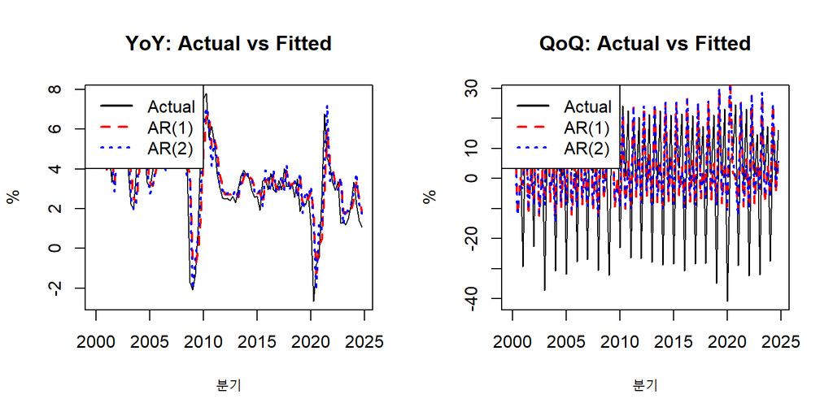

```r
# 시각화(적합값 vs 실제)
par(mfrow=c(1,2))
plot(yoy_ts, main="YoY: Actual vs Fitted", ylab="%", xlab="분기")
lines(fitted(yoy_ar1), col="red", lty=2, lwd=2)
lines(fitted(yoy_ar2), col="blue", lty=3, lwd=2)
legend("topleft", c("Actual","AR(1)","AR(2)"),
       col=c("black","red","blue"), lty=c(1,2,3), lwd=2)

plot(qoq_ts, main="QoQ: Actual vs Fitted", ylab="%", xlab="분기")
lines(fitted(qoq_ar1), col="red", lty=2, lwd=2)
lines(fitted(qoq_ar2), col="blue", lty=3, lwd=2)
legend("topleft", c("Actual","AR(1)","AR(2)"),
       col=c("black","red","blue"), lty=c(1,2,3), lwd=2)
```

```r
par(mfrow=c(1,1))
```

**AIC/BIC, 오차지표 비교**

```r
cat("---- YoY ----\n")
```

```
## ---- YoY ----
```

```r
cat("AR(1) AIC:", AIC(yoy_ar1), " BIC:", BIC(yoy_ar1), "\n")
```

```
## AR(1) AIC: 335.3737  BIC: 343.0667
```

```r
cat("AR(2) AIC:", AIC(yoy_ar2), " BIC:", BIC(yoy_ar2), "\n\n")
```

```
## AR(2) AIC: 324.621  BIC: 334.8784
```

```r
cat("---- QoQ ----\n")
```

```
## ---- QoQ ----
```

```r
cat("AR(1) AIC:", AIC(qoq_ar1), " BIC:", BIC(qoq_ar1), "\n")
```

```
## AR(1) AIC: 831.494  BIC: 839.2793
```

```r
cat("AR(2) AIC:", AIC(qoq_ar2), " BIC:", BIC(qoq_ar2), "\n\n")
```

```
## AR(2) AIC: 832.4952  BIC: 842.8756
```

```r
mse <- function(e) mean(e^2, na.rm=TRUE)
mape <- function(e, y) mean(abs(e/y)*100, na.rm=TRUE)

cat("YoY MSE/MAPE\n")
```

```
## YoY MSE/MAPE
```

```r
cat("AR(1):", mse(residuals(yoy_ar1)), "/", mape(residuals(yoy_ar1), yoy_ts), "\n")
```

```
## AR(1): 1.793051 / 33.83091
```

```r
cat("AR(2):", mse(residuals(yoy_ar2)), "/", mape(residuals(yoy_ar2), yoy_ts), "\n\n")
```

```
## AR(2): 1.565686 / 34.68819
```

**잔차 진단**: 잔차가 백색잡음(자기상관 없음)인가?

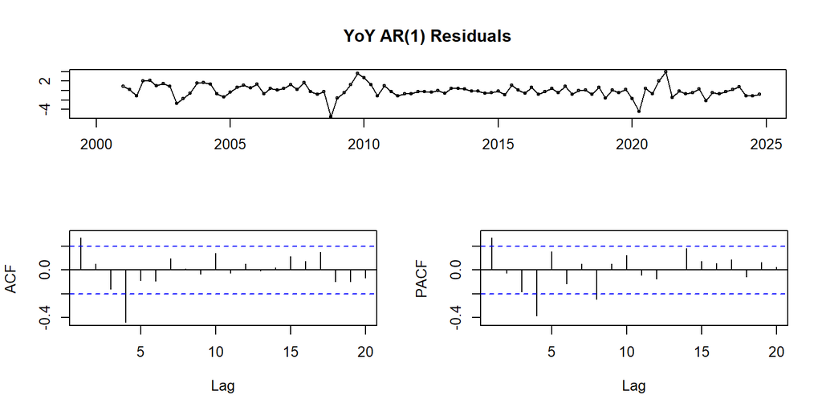

```r
tsdisplay(residuals(yoy_ar1), main="YoY AR(1) Residuals")
```

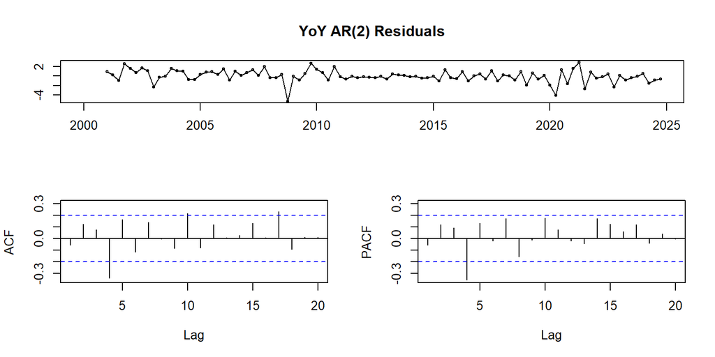

```r
tsdisplay(residuals(yoy_ar2), main="YoY AR(2) Residuals")
```

```r
Box.test(residuals(yoy_ar1), lag=12, type="Ljung-Box")
```

```
##
##  Box-Ljung test
##
## data:  residuals(yoy_ar1)
## X-squared = 35.352, df = 12, p-value = 0.0004115
```

```r
Box.test(residuals(yoy_ar2), lag=12, type="Ljung-Box")
```

```
##
##  Box-Ljung test
##
## data:  residuals(yoy_ar2)
## X-squared = 28.803, df = 12, p-value = 0.004215
```

> **해석**: p-value ≥ 0.05 → “자기상관 없다”는 귀무가설을 기각하지 못함 → 모형 타당성에 우호적.

# 9 예측 성능(MSFE) 비교: 학습/테스트 분할

```r
train_end  <- c(2018,4)
test_start <- c(2019,1)

yoy_train <- window(yoy_ts, end=train_end)
yoy_test  <- window(yoy_ts, start=test_start)

# AR(1)로 학습
fit_ar1 <- arima(yoy_train, order=c(1,0,0))
fc_ar1  <- forecast(fit_ar1, h = length(yoy_test))
pred_ar1 <- fc_ar1$mean

msfe_ar1 <- mean((yoy_test - pred_ar1)^2, na.rm=TRUE)
msfe_ar1
```

```
## [1] 6.681554
```

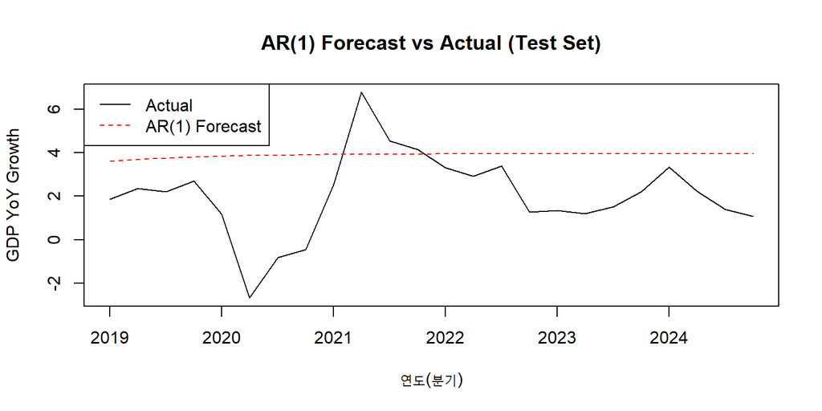

```r
ts.plot(yoy_test, pred_ar1, col=c("black","red"), lty=c(1,2),
        main="AR(1) Forecast vs Actual (Test Set)",
        ylab="GDP YoY Growth", xlab="연도(분기)")
legend("topleft", c("Actual","AR(1) Forecast"),
       col=c("black","red"), lty=c(1,2))
```

> **팁**: 진짜 현업에서는 **롤링/확장 창**(walk-forward)으로 다수의 예측 실험을 수행해 평균 MSFE를 비교한다.

# 10 시뮬레이션 기반 Fan Chart

> **아이디어**: 적합된 AR 모형으로 미래 경로를 다수 시뮬레이션 → 분위수 띠로 불확실성을 시각화.

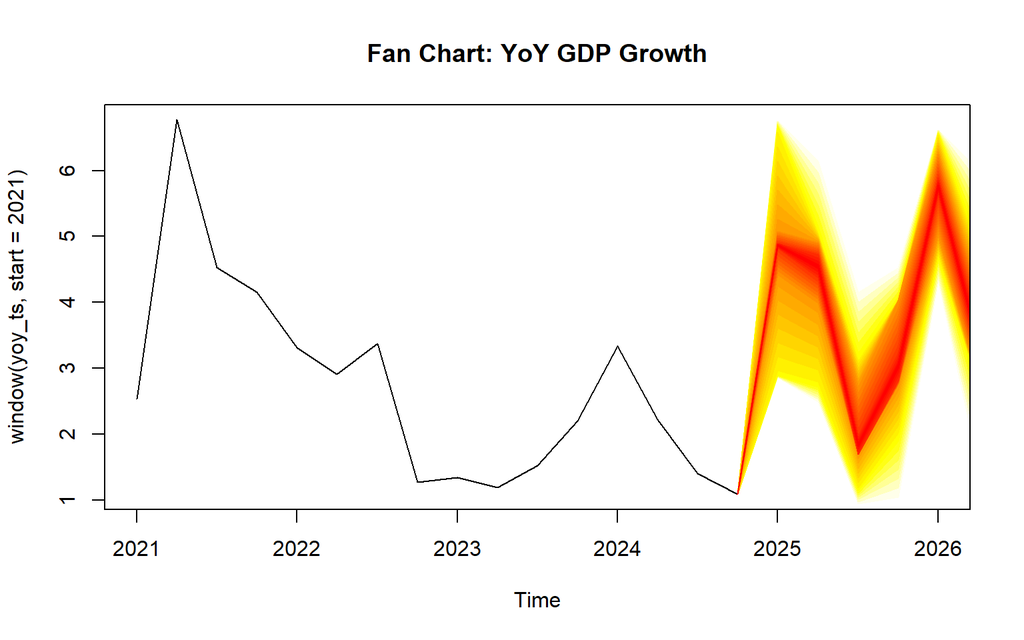

```r
set.seed(123)
n_sim <- 1000
h <- 8

sim_mat <- replicate(n_sim, simulate(fit_ar1, nsim=h, future=TRUE))
fc_ts   <- ts(sim_mat, start=end(yoy_ts) + c(0,1), frequency=4)

plot(window(yoy_ts,start=2021), xlim=c(2021, 2026),
     main="Fan Chart: YoY GDP Growth")
fan(fc_ts, probs=seq(1, 99, by=2),
    start = as.numeric(floor(time(fc_ts)[1])),
    frequency = 4,
    anchor = tail(yoy_ts,1),
    fan.col = heat.colors, ln.col = "red")
```

# 11 ARDL: 스프레드(장단기 금리차)와 성장률

> **이론 요약**  
> - **ARDL(p, q)**: $y_t$의 시차(p)와 설명변수 $x_t$의 시차(q)를 함께 포함.  
> - 단기 동학과(시차항) **장기균형(장기계수)**를 동시에 추정할 수 있어 거시·금융 실증에서 유용.  
> - 혼합적분 차수(I(0)/I(1) 혼재)에서도 **Bounds Test**로 공적분을 점검(본 문서에선 모형 적합 데모 위주).

```r
# 90일물 CD 금리
통계표코드 <- "721Y001"
주기 <- "Q"
검색시작일자 <- "2001Q1"
검색종료일자 <- "2024Q4"
통계항목코드1 <- "2010000"

url_cd <- paste(url_base, id, 요청유형, 언어구분, 요청시작건수, 요청종료건수,
                통계표코드, 주기, 검색시작일자, 검색종료일자, 통계항목코드1, sep="/")
res_cd <- GET(url_cd); stopifnot(status_code(res_cd)==200)
cd_chr <- rawToChar(res_cd$content); Encoding(cd_chr) <- "UTF-8"
cd_df  <- as.data.frame(fromJSON(cd_chr))
CD90   <- as.numeric(cd_df[, 15])

# 10년 국채금리
통계항목코드1 <- "5050000"
url_b10 <- paste(url_base, id, 요청유형, 언어구분, 요청시작건수, 요청종료건수,
                 통계표코드, 주기, 검색시작일자, 검색종료일자, 통계항목코드1, sep="/")
res_b10 <- GET(url_b10); stopifnot(status_code(res_b10)==200)
b10_chr <- rawToChar(res_b10$content); Encoding(b10_chr) <- "UTF-8"
b10_df  <- as.data.frame(fromJSON(b10_chr))
B10Y    <- as.numeric(b10_df[, 15])

Spread <- B10Y - CD90
Spread_ts <- ts(Spread, start=c(2001,1), frequency=4)

# 종속: QoQ 성장률 (동일 기간으로 자름)
qoq_ts1 <- window(qoq_ts, start=c(2001,1))
df_ardl <- data.frame(
  GDP = as.numeric(qoq_ts1),
  Spread = as.numeric(window(Spread_ts, start=start(qoq_ts1), end=end(qoq_ts1)))
)

summary(df_ardl)
```

```
##       GDP              Spread
##  Min.   :-40.883   Min.   :-0.4530
##  1st Qu.: -7.563   1st Qu.: 0.2140
##  Median :  7.262   Median : 0.7055
##  Mean   :  3.416   Mean   : 0.7828
##  3rd Qu.: 21.082   3rd Qu.: 1.1612
##  Max.   : 28.260   Max.   : 2.8200
```

**자동 차수 선택(정보량 기준)**

```r
ardl_auto <- auto_ardl(GDP ~ Spread, data = df_ardl,
                       max_order = c(4,4), selection = "AIC")
ardl_auto
```

```
## $best_model
##
## Time series regression with "ts" data:
## Start = 5, End = 96
##
## Call:
## dynlm::dynlm(formula = full_formula, data = data, start = start,
##     end = end)
##
## Coefficients:
##  (Intercept)     L(GDP, 1)     L(GDP, 2)     L(GDP, 3)     L(GDP, 4)
##      1.71772      -0.25209      -0.23777      -0.26998       0.70108
##       Spread  L(Spread, 1)  L(Spread, 2)  L(Spread, 3)  L(Spread, 4)
##      0.97397       2.35390      -0.02342       1.00065      -1.92756
##
##
## $best_order
##    GDP Spread
##      4      4
##
## $top_orders
##    GDP Spread      AIC
## 1    4      4 566.9589
## 2    3      4 620.0965
## 3    3      3 624.7504
## 4    1      4 772.0786
## 5    2      4 772.4549
## 6    1      3 778.6249
## 7    2      3 779.1521
## 8    1      2 788.3866
## 9    2      2 789.0689
## 10   1      1 794.1590
```

**수동 지정(예: ARDL(2,1))**

```r
ardl_manual <- ardl(GDP ~ Spread, data = df_ardl, order = c(2,1))
summary(ardl_manual)
```

```
##
## Time series regression with "ts" data:
## Start = 3, End = 96
##
## Call:
## dynlm::dynlm(formula = full_formula, data = data, start = start,
##     end = end)
##
## Residuals:
##      Min       1Q   Median       3Q      Max
## -30.0717 -14.2832   0.0502  13.6507  26.6906
##
## Coefficients:
##              Estimate Std. Error t value Pr(>|t|)
## (Intercept)    3.8425     2.3960   1.604    0.112
## L(GDP, 1)     -0.7772     0.1040  -7.471 5.22e-11 ***
## L(GDP, 2)     -0.1258     0.1019  -1.236    0.220
## Spread        -4.9920     4.2632  -1.171    0.245
## L(Spread, 1)   8.4987     4.3147   1.970    0.052 .
## ---
## Signif. codes:  0 '***' 0.001 '**' 0.01 '*' 0.05 '.' 0.1 ' ' 1
##
## Residual standard error: 15.36 on 89 degrees of freedom
## Multiple R-squared:  0.4867, Adjusted R-squared:  0.4637
## F-statistic:  21.1 on 4 and 89 DF,  p-value: 2.918e-12
```

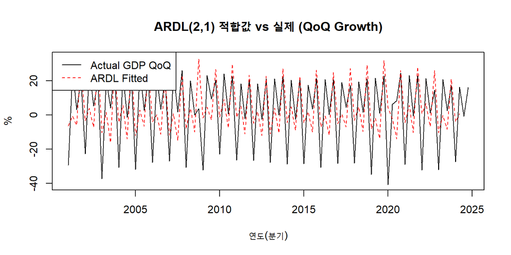

```r
# 적합값 비교 시각화
fit_vals <- fitted(ardl_manual)
ts.plot(ts(df_ardl$GDP, start=c(2001,1), frequency=4),
        ts(fit_vals, start=c(2001,1), frequency=4),
        col=c("black","red"), lty=c(1,2),
        main="ARDL(2,1) 적합값 vs 실제 (QoQ Growth)",
        ylab="%", xlab="연도(분기)")
legend("topleft", c("Actual GDP QoQ","ARDL Fitted"),
       col=c("black","red"), lty=c(1,2))
```

> **해석 포인트**  
> - **단기 효과**: 시차 포함된 회귀계수.  
> - **장기 효과**: $x$ 계수들을 장기균형식으로 변환해 계산(패키지 도우미 함수 활용 가능).  
> - **주의**: ARDL 적용 전 각 변수의 적분 차수(I(0)/I(1)) 점검 권장, I(2) 변수가 섞이면 표준 절차가 깨짐.

# 12 정리 & 과제

- **정상성**과 **단위근 검정**을 실습했고, **AR 모형**으로 적합·진단·예측을 해보았다.
- **Fan chart**로 예측 불확실성을 시각화했고, **ARDL**로 금리 스프레드의 동태적 영향도 살펴봤다.

**과제**  
1) YoY 대신 **QoQ**에 대해 AIC/BIC, 잔차진단, 테스트셋 MSFE를 다시 비교해 보고 모형을 선택하라.  
2) ARDL에서 `Spread` 대신 **실업률**이나 **소비자심리지수**(ECOS에서 구해보기)를 넣어 결과를 비교하라.  
3) Zivot–Andrews 변동점이 있는 월별 산업생산 지수를 찾아 단위근 검정을 반복해 보라.

# 13 부록: 흔한 오류와 해결

- **ECOS 403/429**: API 키/호출 한도 문제 → 키 확인·호출 간격 조절.
- **NA/비정상**: 로그/차분 전 0·음수 여부 확인.
- **ADF 옵션 선택**: 추세가 뚜렷하면 `type="trend"`, 그렇지 않으면 `drift/none`.
- **fanplot start/anchor**: `start`, `frequency`, `anchor`를 실제 시계열과 일치시키기.